# HaploTraitR Package Usage

This R Markdown document provides a tutorial for using the `HaploTraitR` package to analyze haplotype clusters, linkage disequilibrium (LD), and SNP combinations and assess their impact on phenotypic traits in barley. The document demonstrates how to read GWAS, hapmap, and phenotype files, compute LD matrices, cluster SNPs, and visualize the results.

## Introduction

This document demonstrates how to use the `HaploTraitR` package to analyze haplotype clusters, linkage disequilibrium (LD), and SNP combinations and assess their impact on phenotypic traits in barley.

We will go through the steps of reading GWAS, hapmap, and phenotype files, computing LD matrices, clustering SNPs, and visualizing the results.

### Input Files

```r
# Define file paths and output folder
hapfile <- "sampledata/Barley_50K_KNNimp.hmp.txt"
gwasfile <- "sampledata/SignificantSNP_GWAS.tsv"
phenofile <- "sampledata/Pheno_ANN19.tsv"
outfolder <- "sampleout"
```

### Setting Thresholds

Set thresholds for distance, clustering, LD, and combination frequency.

```r
dist_threshold <- 1000000 # Distance threshold (1Mb)
dist_cluster_count <- 5   # Minimum SNPs in a cluster
ld_threshold <- 0.3       # Minimum LD value
comb_freq_threshold <- 0.1 # Minimum genotype frequency for a combination
```

## Step 1: Reading Data Files

### Load GWAS Data

First, load the GWAS data to identify significant SNPs for clustering.

```r
gwas <- readGWAS(gwasfile, sep = "\t")
head(gwas)
```

```
## $`2H`
##                     rs chr      pos        p
## 1 JHI-Hv50k-2016-79446  2H 48081081 6.17e-05
## 2 JHI-Hv50k-2016-79537  2H 48269792 7.32e-05
## 3 JHI-Hv50k-2016-79696  2H 48579641 8.87e-05
##
## $`7H`
##                       rs chr       pos        p
## 4  JHI-Hv50k-2016-459633  7H  36696445 5.78e-05
## 5  JHI-Hv50k-2016-488067  7H 482468420 6.69e-05
## 6  JHI-Hv50k-2016-489031  7H 496430435 1.46e-06
## 7  JHI-Hv50k-2016-489053  7H 496915681 4.38e-07
## 8  JHI-Hv50k-2016-489254  7H 498717095 2.42e-06
## 9  JHI-Hv50k-2016-489219  7H 498984440 4.65e-07
## 10 JHI-Hv50k-2016-489205  7H 499071082 4.38e-07
## 11 JHI-Hv50k-2016-489174  7H 499404297 4.65e-07
## 12 JHI-Hv50k-2016-489168  7H 499407586 4.65e-07
## 13 JHI-Hv50k-2016-489164  7H 499432845 4.65e-07
## 14 JHI-Hv50k-2016-489156  7H 499444013 4.65e-07
## 15 JHI-Hv50k-2016-489144  7H 499462679 4.38e-07
## 16 JHI-Hv50k-2016-489129  7H 499788000 4.38e-07
## 17 JHI-Hv50k-2016-489103  7H 500129030 4.38e-07
## 18        SCRI_RS_169649  7H 501592821 1.09e-05
## 19 JHI-Hv50k-2016-489587  7H 502433203 1.71e-05
```

### Load Haplotype Data

Load the hapmap file to access genotype data for the analysis.

```r
hapmap <- readHapmap(hapfile)
```

```
## warning: duplicated rsid found, it will be removed!
```

## Step 2: Cluster SNPs by Chromosome

Cluster SNPs within the specified distance threshold around significant SNPs from the GWAS data.

```r
haplotype_clusters <- getHaplotypeClusters(gwas, hapmap, dist_threshold, dist_cluster_count)
```

## Step 3: Compute LD Matrices

Calculate linkage disequilibrium (LD) values for each SNP cluster.

```r
LDsInfo <- computeLDclusters(hapmap, haplotype_clusters)
```

## Step 4: Save LD Matrices

Save the LD matrices to the specified output folder.

```r
saveLDs2folder(LDsInfo, outfolder)
```

## Step 5: Cluster LD Values and Convert to Haplotypes

Cluster SNPs based on LD values and apply frequency thresholding to derive haplotypes.

```r
clusterLDs <- clusterLD(LDsInfo, ld_threshold, cls_count = 3)
haplotypes <- convertLDclusters2Haps(hapmap, clusterLDs, comb_freq_threshold)
```

## Step 6: Get Sample Haplotypes and Save

Extract the haplotype combinations for samples and save to a CSV file.

```r
snpcombsample <- getHapCombSamples(haplotypes, hapmap)
snpcombsample <- as.data.frame(snpcombsample)
write.csv(snpcombsample, file = file.path(outfolder, "haplotype_combinations.csv"), row.names = FALSE)
```

## Step 7: Read Phenotype Data

Read the phenotype data for associating haplotypes with phenotypic traits.

```r
pheno <- read.csv(phenofile, header = TRUE, sep = "\t")
head(pheno)
```

```
##   Taxa       PH
## 1   G1 96.76140
## 2   G2 70.56720
## 3   G3 77.16486
## 4   G4 79.22446
## 5   G5 71.78375
## 6   G7 88.70248
```

## Step 8: Generate SNP Combination Tables

Generate tables to link SNP combinations with phenotype data.

```r
SNPcombTables <- getSNPcombTables(snpcombsample, pheno)
```

## Step 9: Perform t-tests on SNP Combinations

Perform statistical testing on SNP combinations to see if there are significant associations with phenotypes.

```r
# I am going to fix this
library(magrittr)
library(rstatix)
#The target code
t_test_snpComp <- testSNPcombs(SNPcombTables)
```

## Step 10: Visualize Results

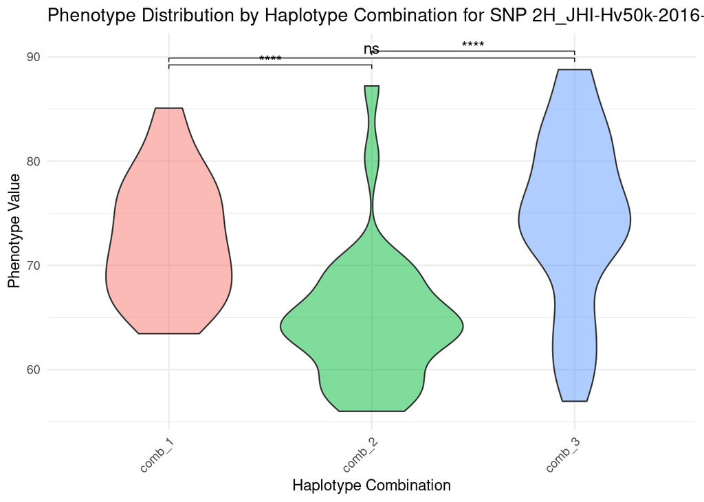

```r
#library(ggplot2)
library(ggpubr)
snp <- "2H_JHI-Hv50k-2016-79696"
plotHapCombBoxPlot(snp, SNPcombTables, t_test_snpComp)
```

### Plot Haplotype Distribution

Visualize the distribution of haplotypes for a specific SNP.

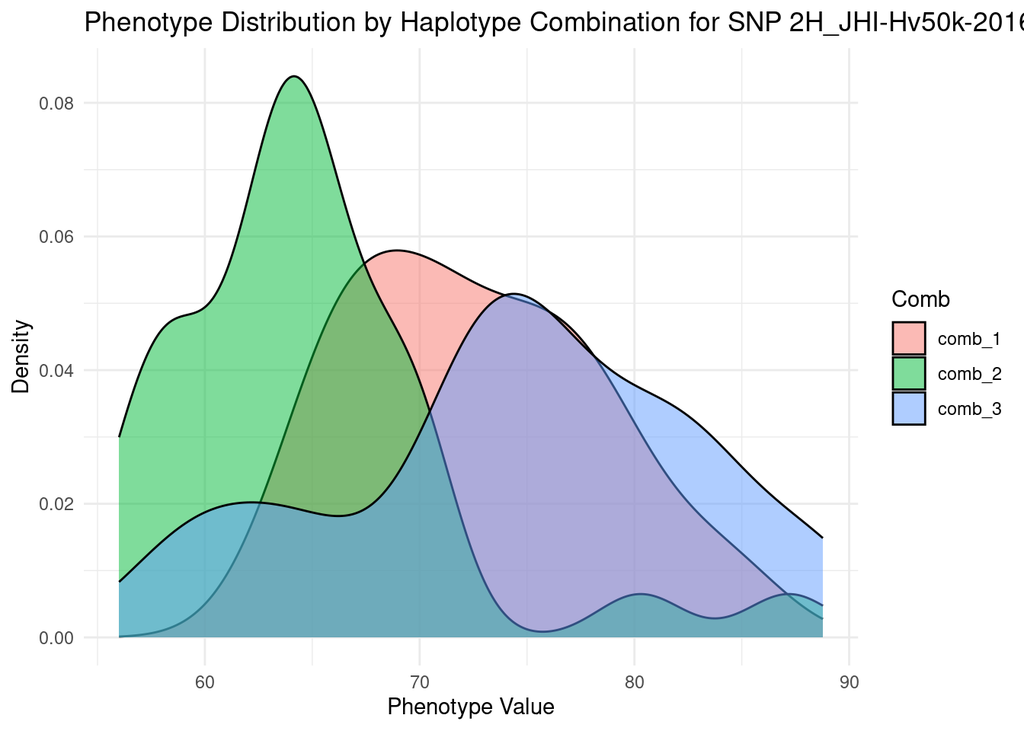

```r
library(ggplot2)
library(dplyr)  # If you are also using %>%
plotHapCombDistribution(snp, SNPcombTables)
```

## Conclusion

This document demonstrated the workflow for analyzing haplotype clusters and their impact on phenotypic traits using the `HaploTraitR` package. This approach can help researchers identify haplotype clusters with significant associations to phenotypic variation and may provide insights for plant breeding and genetic research.